# Military Pentathlon Jørstadmoen 2025

WELCOME CADETS’

Sjur Fortun Øfsteng | PhD

Norwegian Defence Cyber Academy

sofsteng@mil.no

## Learning pathway

- From theory into practice **(1)**
  - Learning platform
  - Cadet led warm-up sessions
- Military pentathlon and military working demands **(2: theory)**  
  - Working demands in the military context  
  - Deployment - operations  
  - Challenges  
  - Training strategies
- Workshop **(3: discussion - reflection - practical)**
  - Working with your working demands
  - Test fitness vs. functional fitness
- Optimizing performance **(4: theory)**  
  - Elaborate upon training methods  
  - Concurrent training - And more…

# The Art of Warming Up - In class

## Today Warming-up session

### From theory into practice **(1)**

- Short recap - Warm-up guidelines
- Cadet presentations
- First cadet led warm-up session outside 😀
- Learning outcomes from this warm-up module:

  1. Knowledge of injury prevention strategies for military personnel

  2. Knowledge of the purpose of warming up prior to exercise

  3. *Knowledge to set up a warm-up program for a specific workout session*

# Warm-up for Injury Prevention and Performance enhancement

## Power of warm-up

### The importance of implementing warm-up sessions

- Equally important (to plan as the main session)
  - effective and keep the overall training load minimal
- Activities that contribute to the aims of the overall session
- Usually ~10-30 min

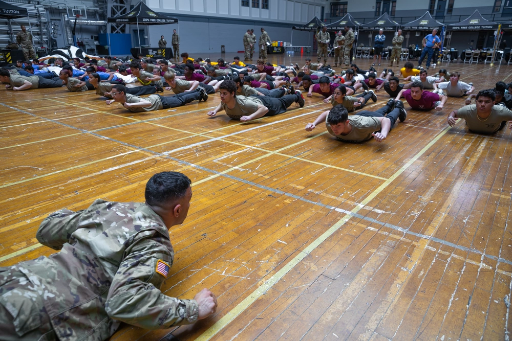

- Excited for your warm-up programs!

## Power of warm-up

### The frequently followed warm-up guideline

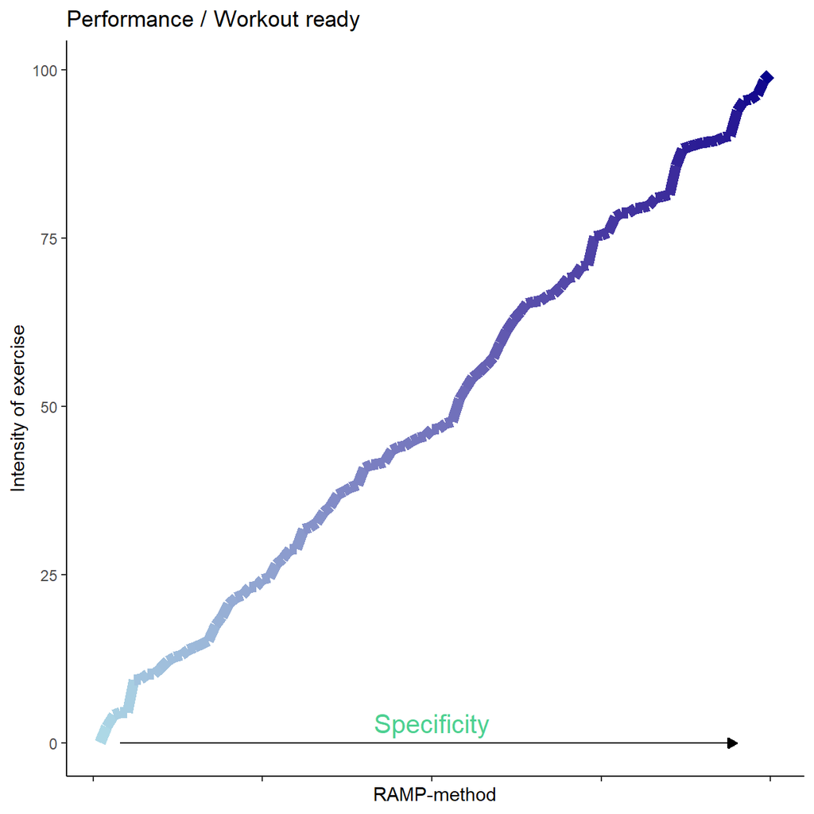

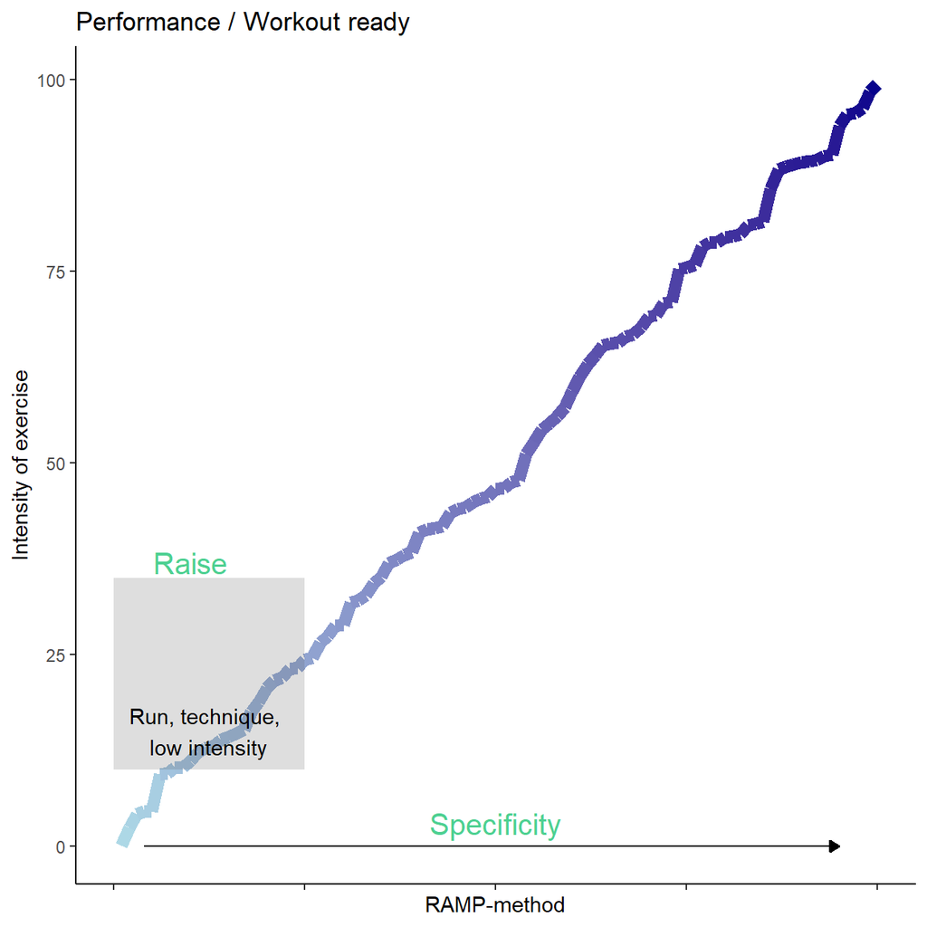

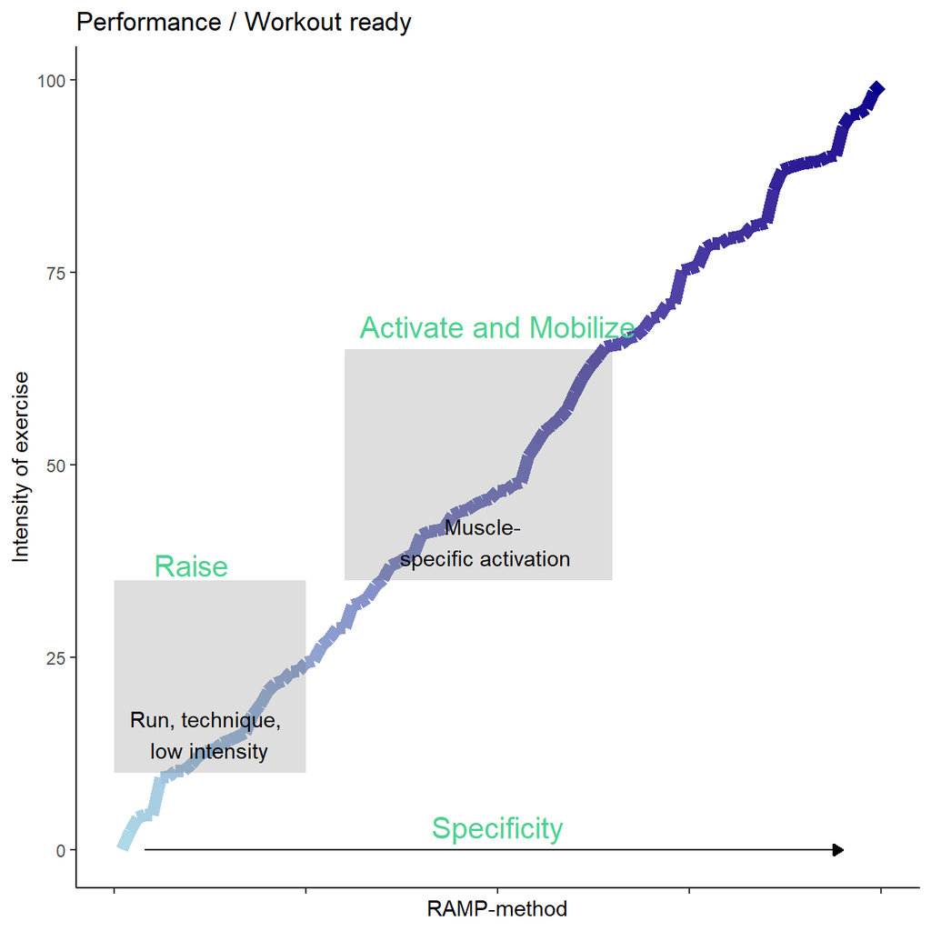

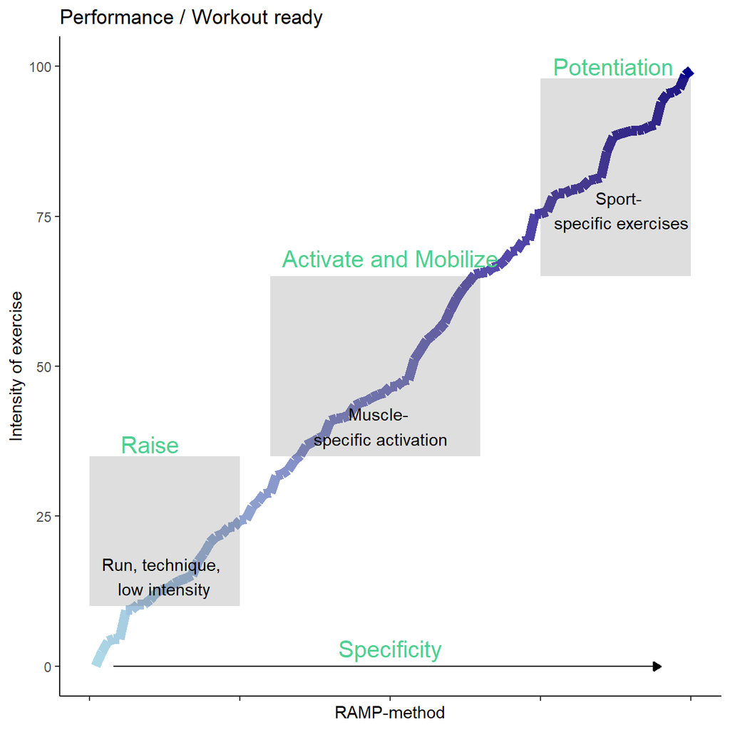

(Figure created with  
inspiration from Jeffreys, I 2007)

## You are our future leaders with PHYSICAL TRAINING COMPETANCE

- Education of military leaders is essential!
- Key training principles:
  - Knowledge of training load and intensity planing (i.e. total training load)
  - Progression of training load and volume
  - Variation - methodology  
    Your knowledge of risk factors and training will contribute to reduce injury prevalence in the military!

# Presentations Academies

Warm-up programs

| Academy | Exercise | Day of warm-up (practice) |
| --- | --- | --- |
| Bulgaria | Obstacle course | Later today |
| Slovakia | Obstacle swimming | Sunday |
| Greece | Grenade throw | Sunday |
| Romania | Obstacle course | Monday |

## References

Jeffreys, I. 2007. “Warm up Revisited: The Ramp Method of Optimising Performance Preparation.” *Prof Strength Cond* 6: 12–18.